# assignment

Saeid Abolfazli (PhD)

May 31, 2016

# Problem 1.1 - Normalizing the Data

Read the dataset AirlinesCluster.csv into R and call it “airlines”.

```r
file <- file.path("data","AirlinesCluster.csv")
airlines <- read.csv(file)
summary(airlines)
```

```
##     Balance          QualMiles         BonusMiles       BonusTrans
##  Min.   :      0   Min.   :    0.0   Min.   :     0   Min.   : 0.0
##  1st Qu.:  18528   1st Qu.:    0.0   1st Qu.:  1250   1st Qu.: 3.0
##  Median :  43097   Median :    0.0   Median :  7171   Median :12.0
##  Mean   :  73601   Mean   :  144.1   Mean   : 17145   Mean   :11.6
##  3rd Qu.:  92404   3rd Qu.:    0.0   3rd Qu.: 23801   3rd Qu.:17.0
##  Max.   :1704838   Max.   :11148.0   Max.   :263685   Max.   :86.0
##   FlightMiles       FlightTrans     DaysSinceEnroll
##  Min.   :    0.0   Min.   : 0.000   Min.   :   2
##  1st Qu.:    0.0   1st Qu.: 0.000   1st Qu.:2330
##  Median :    0.0   Median : 0.000   Median :4096
##  Mean   :  460.1   Mean   : 1.374   Mean   :4119
##  3rd Qu.:  311.0   3rd Qu.: 1.000   3rd Qu.:5790
##  Max.   :30817.0   Max.   :53.000   Max.   :8296
```

Looking at the summary of airlines, which TWO variables have (on average) the smallest values?

Which TWO variables have (on average) the largest values?

**Answer:** Balance BonusMiles

# Problem 1.2 - Normalizing the Data

In this #Problem, we will normalize our data before we run the clustering algorithms. Why is it important to normalize the data before clustering?

**Answer:** If we don’t normalize the data, the clustering will be dominated by the variables that are on a larger scale.

# Problem 1.3 - Normalizing the Data

Let’s go ahead and normalize our data. You can normalize the variables in a data frame by using the preProcess function in the “caret” package. You should already have this package installed from Week 4, but if not, go ahead and install it with install.packages(“caret”). Then load the package with library(caret).

```r
library(caret)
```

Now, create a normalized data frame called “airlinesNorm” by running the following commands:

```r
preproc <- preProcess(airlines)
airlinesNorm <- predict(preproc, airlines)
summary(airlinesNorm)
```

```
##     Balance          QualMiles         BonusMiles        BonusTrans
##  Min.   :-0.7303   Min.   :-0.1863   Min.   :-0.7099   Min.   :-1.20805
##  1st Qu.:-0.5465   1st Qu.:-0.1863   1st Qu.:-0.6581   1st Qu.:-0.89568
##  Median :-0.3027   Median :-0.1863   Median :-0.4130   Median : 0.04145
##  Mean   : 0.0000   Mean   : 0.0000   Mean   : 0.0000   Mean   : 0.00000
##  3rd Qu.: 0.1866   3rd Qu.:-0.1863   3rd Qu.: 0.2756   3rd Qu.: 0.56208
##  Max.   :16.1868   Max.   :14.2231   Max.   :10.2083   Max.   : 7.74673
##   FlightMiles       FlightTrans       DaysSinceEnroll
##  Min.   :-0.3286   Min.   :-0.36212   Min.   :-1.99336
##  1st Qu.:-0.3286   1st Qu.:-0.36212   1st Qu.:-0.86607
##  Median :-0.3286   Median :-0.36212   Median :-0.01092
##  Mean   : 0.0000   Mean   : 0.00000   Mean   : 0.00000
##  3rd Qu.:-0.1065   3rd Qu.:-0.09849   3rd Qu.: 0.80960
##  Max.   :21.6803   Max.   :13.61035   Max.   : 2.02284
```

The first command pre-processes the data, and the second command performs the normalization. If you look at the summary of airlinesNorm, you should see that all of the variables now have mean zero. You can also see that each of the variables has standard deviation 1 by using the sd() function.

In the normalized data, which variable has the largest maximum value?

**Answer:** FlightMiles

In the normalized data, which variable has the smallest minimum value?

**Answer:** DaysSinceEnroll

# Problem 2.1 - Hierarchical Clustering

Compute the distances between data points (using euclidean distance) and then run the Hierarchical clustering algorithm (using method=“ward.D”) on the normalized data. It may take a few minutes for the commands to finish since the dataset has a large number of observations for hierarchical clustering.

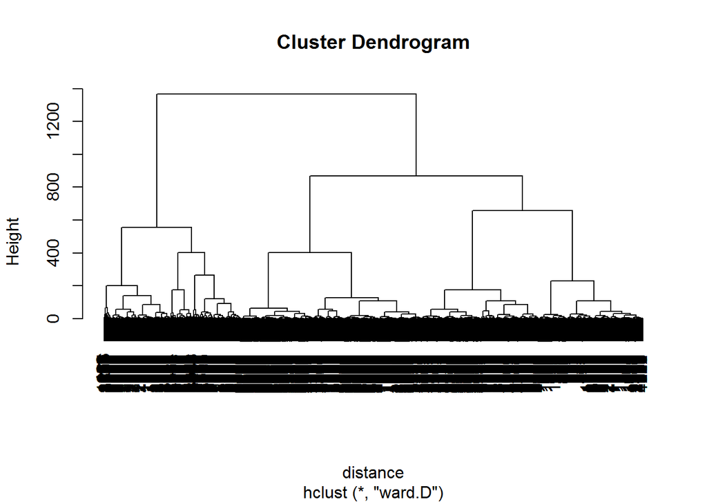

```r
distance <- dist(airlinesNorm, method = "euclidean")
Cluster <- hclust(distance, method = "ward.D")
plot(Cluster)
```

Then, plot the dendrogram of the hierarchical clustering process. Suppose the airline is looking for somewhere between 2 and 10 clusters. According to the dendrogram, which of the following is NOT a good choice for the number of clusters?

**Answer:** 6

# Problem 2.2 - Hierarchical Clustering

Suppose that after looking at the dendrogram and discussing with the marketing department, the airline decides to proceed with 5 clusters. Divide the data points into 5 clusters by using the cutree function. How many data points are in Cluster 1?

```r
ClusterIndex <- cutree(Cluster , k = 5)
c1 <- subset(airlines,ClusterIndex == 1)
nrow(c1)
```

```
## [1] 776
```

# Problem 2.3 - Hierarchical Clustering

Now, use tapply to compare the average values in each of the variables for the 5 clusters (the centroids of the clusters). You may want to compute the average values of the unnormalized data so that it is easier to interpret. You can do this for the variable “Balance” with the following command:

```r
library(dplyr)
tapply(airlines$Balance, ClusterIndex, mean) %>% sort
```

```
##         5         4         1         2         3
##  36255.91  52335.91  57866.90 110669.27 198191.57
```

```r
tapply(airlines$QualMiles, ClusterIndex, mean) %>% sort
```

```
##            1            5            4            3            2
##    0.6443299    2.5111773    4.8479263   30.3461538 1065.9826590
```

```r
tapply(airlines$BonusMiles, ClusterIndex, mean)%>% sort
```

```
##         5         1         4         2         3
##  2264.788 10360.124 20788.766 22881.763 55795.860
```

```r
tapply(airlines$BonusTrans, ClusterIndex, mean)%>% sort
```

```
##         5         1         4         2         3
##  2.973174 10.823454 17.087558 18.229287 19.663968
```

```r
tapply(airlines$FlightMiles, ClusterIndex, mean)%>% sort
```

```
##          1          4          5          3          2
##   83.18428  111.57373  119.32191  327.67611 2613.41811
```

```r
tapply(airlines$FlightTrans, ClusterIndex, mean)%>% sort
```

```
##         1         4         5         3         2
## 0.3028351 0.3444700 0.4388972 1.0688259 7.4026975
```

```r
tapply(airlines$DaysSinceEnroll, ClusterIndex, mean)%>% sort
```

```
##        4        5        2        3        1
## 2840.823 3060.081 4402.414 5615.709 6235.365
```

Compared to the other clusters, Cluster 1 has the largest average values in which variables (if any)? Select all that apply.

DaysSinceEnroll

How would you describe the customers in Cluster 1?

** Answer:** Infrequent but loyal customers.

# Problem 2.4 - Hierarchical Clustering

Compared to the other clusters, Cluster 2 has the largest average values in which variables (if any)? Select all that apply.

**Answer:** QualMiles, FlightMiles , flightTrans

How would you describe the customers in Cluster 2?

**Answer:** Customers who have accumulated a large amount of miles, and the ones with the largest number of flight transactions.

# Problem 2.5 - Hierarchical Clustering

Compared to the other clusters, Cluster 3 has the largest average values in which variables (if any)? Select all that apply.

Balance, BonusMiles, BonusTrans

How would you describe the customers in Cluster 3?

**Answer:** Customers who have accumulated a large amount of miles, mostly through non-flight transactions.

# Problem 2.6 - Hierarchical Clustering

Compared to the other clusters, Cluster 4 has the largest average values in which variables (if any)? Select all that apply.

*Answer:** None

How would you describe the customers in Cluster 4?

**Answer:** Relatively new customers who seem to be accumulating miles, mostly through non-flight transactions.

# Problem 2.7 - Hierarchical Clustering

Compared to the other clusters, Cluster 5 has the largest average values in which variables (if any)? Select all that apply.

*Answer:** None

How would you describe the customers in Cluster 5?

**Answer:** Relatively new customers who don’t use the airline very often. Relatively new customers who don’t use the airline very often. - correct

# Problem 3.1 - K-Means Clustering

Now run the k-means clustering algorithm on the normalized data, again creating 5 clusters. Set the seed to 88 right before running the clustering algorithm, and set the argument iter.max to 1000.

```r
kmean_Cluster <- kmeans(airlinesNorm, centers = 5, iter.max = 1000)
str(kmean_Cluster)
```

```
## List of 9
##  $ cluster     : int [1:3999] 1 1 1 1 3 1 5 1 2 5 ...
##  $ centers     : num [1:5, 1:7] -0.1333 1.0005 1.4444 -0.4058 -0.0558 ...
##   ..- attr(*, "dimnames")=List of 2
##   .. ..$ : chr [1:5] "1" "2" "3" "4" ...
##   .. ..$ : chr [1:7] "Balance" "QualMiles" "BonusMiles" "BonusTrans" ...
##  $ totss       : num 27986
##  $ withinss    : num [1:5] 2040 3624 4948 2321 2054
##  $ tot.withinss: num 14987
##  $ betweenss   : num 12999
##  $ size        : int [1:5] 1182 141 408 1275 993
##  $ iter        : int 4
##  $ ifault      : int 0
##  - attr(*, "class")= chr "kmeans"
```

How many clusters have more than 1,000 observations?

**Answer:** 2

# Problem 3.2 - K-Means Clustering

Now, compare the cluster centroids to each other either by dividing the data points into groups and then using tapply, or by looking at the output of kmeansClust$centers, where "kmeansClust" is the name of the output of the kmeans function. (Note that the output of kmeansClust$centers will be for the normalized data. If you want to look at the average values for the unnormalized data, you need to use tapply like we did for hierarchical clustering.)

```r
table(kmean_Cluster$cluster, ClusterIndex)
```

```
##    ClusterIndex
##        1    2    3    4    5
##   1  673   92   58   30  329
##   2    0  137    4    0    0
##   3    4   92  300   12    0
##   4    1   93    0  173 1008
##   5   98  105  132  653    5
```

Do you expect Cluster 1 of the K-Means clustering output to necessarily be similar to Cluster 1 of the Hierarchical clustering output?

**Answer:** No, because cluster ordering is not meaningful in either k-means clustering or hierarchical clustering.